# HG4052 · Week 1 · Inside the Black Box

HG4052 · Speech Synthesis & Recognition

Jump to a slide · M or O toggles · Esc closes

ə

HG4052 · Speech Synthesis & Recognition / Week 1

# Inside the Black Box.

Sounds and Numbers.

Chenzi Xu · chenzi.xu@ntu.edu.sg

→ / space to advance · F for fullscreen · M for the slide menu

Today

## Roadmap

- Automatic speech **recognition** and **synthesis** demo
- Course **overview**
- The **history** of the field
- The reframe: recorded speech is **a long list of numbers**
- Math primer: **vectors, matrices, and similarity**

t

The shape of the morning

## Today, by the clock

**09:40** Lecture I: two live demos, the field, and seventy years of history

**10:40** Break (10 min)

**10:50** Lecture II: sounds become numbers; vectors, matrices & similarity

**11:40** Break + Colab setup (10 min)

**11:50** Practical: from zero Python to a vowel space you built

**12:50** Wrap-up

Live demo

## Two machines you already carry

DEMO 1 · ASR

### Your phone takes dictation

Before we start: predict what survives. Someone dictates a sentence with a proper name and a hesitation in it. Watch what gets silently "repaired".

DEMO 2 · TTS

### Your phone talks back

A screen-reader voice reads the same sentence. Listen for what it gets right effortlessly, and where it doesn't sound human.

By Week 13 you will be able to explain, and *audit*, both of these, level by level.

Listen closer

## Two sentences that bite back

TTS · SENTENCE 1

### “I live near the live music venue.”

Same four letters, two pronunciations. The voice must parse the sentence before it can say it. (How? Week 10.)

TTS · SENTENCE 2

### “OK lah, see you there lor.”

The segments are easy; the meaning lives in the particles’ pitch. Listen to what the voice does to *lah*. (Prosody: Week 12.)

Score it as phoneticians: what does it get right effortlessly, and what is subtly wrong? Keep your notes; both sentences return in Weeks 10–12.

ʔ

Activity · predict first, then watch

## Does it speak Singlish?

Before the demo: write down, word for word, what you think the recognizer will print for this sentence.

Dictated live (fallback: pre-recorded screen capture)

“Can lah, we go makan at the kopitiam after this.”

Hands up: who predicted *lah* survives? Who predicted *makan*? *kopitiam*?

Debrief

## Whose English does it speak?

### Deleted

Discourse particles (*lah, lor, leh*) tend to vanish: the system has no word for them.

### Rewritten

*makan* and *kopitiam* get “repaired” into the nearest English the model knows.

### Standardized

The output is fluent, punctuated, and someone else’s English. Fluency is not accuracy.

Our home dataset: the **IMDA National Speech Corpus**, thousands of hours of Singapore speech. Assignment 1 works with it; in Week 9 we audit accent bias with it. **This course treats Singapore as the test set.**

The wide shot

## One field, six doors

PILLAR 1 · WEEKS 5–9

### Speech recognition (ASR)

Speech in, text out: dictation, captions, voice search, transcription at scale.

PILLAR 2 · WEEKS 10–12

### Speech synthesis (TTS)

Text in, speech out: screen readers, assistant voices, audiobooks, voice banking.

### Who spoke?

Speaker recognition & diarization: voice ID, meeting minutes. W12

### Where are the sounds?

Forced alignment: the corpus phonetician’s power tool. W9

### Across languages

Speech-to-speech translation and voice conversion. W13

### Talking back

Spoken dialogue: assistants that listen while they speak. W13

One toolbox underneath all six: **features, similarity, probability, networks**. That toolbox is Weeks 1–4 and 7, and it opens today.

The course at a glance

## Welcome to HG4052!

Goals.

1. Understand how speech **recognition** and **synthesis** systems **work**, and where **linguistics** fits in
2. Learn to **evaluate** and **use** them in research, with **Singapore's speech** as a running case

Audience.

- Interested in speech technology
  - Career goal: speech and language technology, research
  - A project: fieldwork, corpus work, a thesis
  - “AI literacy” or curiosity
- Prerequisite: HG2003 Phonetics & Phonology; secondary-school maths
- Programming: not required, but some basics are a plus (all Python runs in Colab)

The map

## Two pipelines, mirror images

[figure not shown]

This is the classical, modular map. Modern end-to-end systems (Weeks 8 & 11) fold the boxes into one network, but every job on this slide still has to happen. Evaluation, bias & ethics cut across everything: Weeks 9 & 12.

The semester

## Thirteen weeks on one slide

W1

Numbers, vectors & similarity

W2

Probability & Bayes

W3

Acoustics: sampling & source–filter

W4

Features: mel & MFCCs

W5

Template matching & DTW

W6

HMMs, Viterbi & lexicons

W7

Neural networks

W8

End-to-end ASR: Whisper

W9

Evaluation, bias & alignment

W10

Classical TTS & G2P

W11

Neural TTS & vocoders

W12

Cloning, prosody & ethics

W13

Frontiers · panel · A2 poster fair

Foundations Recognition Synthesis Shaded = assessment Quiz 1 in W6 · A1 due W10 · Quiz 2 in W12 · A2 fair in W13

How you're graded

## Assessment

QUIZ 1 · 20%

### Week 6, in class

First 45 minutes; covers Weeks 1–5. Knowledge-based plus interpretive questions; full details nearer the quiz.

QUIZ 2 · 20%

### Week 12, in class

First 45 minutes; covers Weeks 6–11. Full details nearer the quiz.

ASSIGNMENT 1 · 30%

### Speech recognition

An applied ASR assignment. Released from Week 7; due Week 10. Full details in the brief.

ASSIGNMENT 2 · 30%

### Speech synthesis

A synthesis assignment, presented at the Week 13 demo/poster fair. Released Week 10. Full details in the brief.

Quiz questions draw on the weekly practicals, so the notebooks are your revision. Week 13 also brings a guest panel: careers in speech technology.

How we got here · I

## Two centuries of talking machines

[figure not shown]

Gold, above the line: machines that **speak**. Teal, below: machines that **listen**. Speaking had a **160-year head start**.

The tube model returns in Week 3, the talking heads as articulatory synthesis in Week 10; the statistical turn (HMMs, and HTK, the toolkit that trained a generation) is what you build in Weeks 5 and 6. Photos: Wikimedia Commons, public domain.

How we got here · up close

## 1791 · The speaking machine

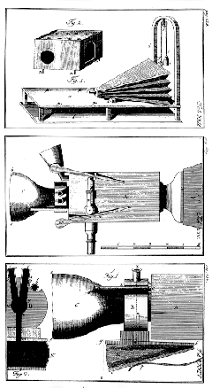

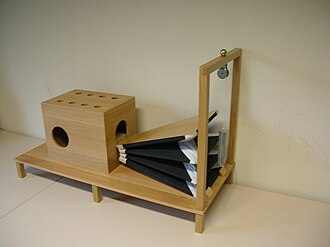

Von Kempelen’s own drawing (1791), via H. Traunmüller, Stockholm University; replica photo: Wikimedia Commons (PD)

- A bellows for lungs, a reed for the voicing, a leather-and-rubber mouth shaped by one hand
- Played like an instrument: years of practice for a few phrases, and a listener to interpret them charitably
- No recording can exist: the phonograph was still 86 years away

Its direct descendants are the articulatory synthesizers of **Week 10**: in class you will play a browser vocal tract (Pink Trombone) that works on exactly von Kempelen’s plan.

How we got here · up close

## 1846 · The Euphonia, a talking head

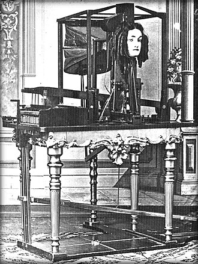

Image: Wikimedia Commons (PD)

- Joseph Faber’s machine: bellows, an ivory tongue, a rubber pharynx and a sixteen-key keyboard behind a mannequin face
- It spoke slowly in several languages, whispered, and sang “God Save the Queen”
- London crowds paid to hear it; a generation later, a rebuilt Kempelen machine set the young Alexander Graham Bell building his own talking head

How we got here · up close

## 1939 · The Voder goes electric

[figure not shown]

Voder demonstration, 1939 New York World’s Fair; Wikimedia Commons (PD)

- The first electrical voice: a buzz source and a hiss source shaped by ten filter keys. **Source–filter theory, built as hardware** (the theory itself is Week 3)
- Operators trained for about a year to “play” sentences by hand
- Its sibling, Dudley’s **vocoder**, gave its name to the neural vocoders of W11

Hear it · “Good evening, radio audience”

[interactive chart not shown]

Recording: D. H. Klatt’s archive, via Acoustics Today

How we got here · up close

## 1951 · Pattern Playback: spectrograms, played

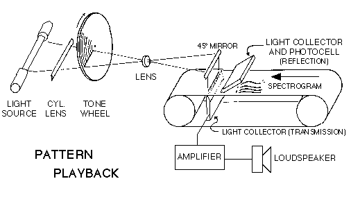

Image: H. Traunmüller, Stockholm University

- Paint a spectrogram, shine light through it, and hear it: **analysis, run backwards**
- With it, Haskins Labs found which patterns matter: formant transitions, cue trading, categorical perception
- Much of the speech perception you learned was discovered **on this machine**

Hear it · hand-painted sentences

[interactive chart not shown]

Recording: D. H. Klatt’s archive, via Acoustics Today

How we got here · up close

## 1953 · OVE & PAT: the first formant synthesizers

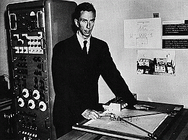

Fant’s OVE; image: H. Traunmüller, Stockholm University

- **OVE** is *Orator Verbis Electris*, a “speaker by electric words”; **PAT**, the Parametric Artificial Talker
- No mouth at all: just a few **formant tracks**, steered over time
- Their rule-driven heirs (Klatt, DECtalk) are W10, where you build vowels in a KlattGrid

OVE (Gunnar Fant, Stockholm) · “How are you? I love you!”

[interactive chart not shown]

PAT (Walter Lawrence, UK) · “What did you say before that?”

[interactive chart not shown]

Recordings: D. H. Klatt’s archive, via Acoustics Today

Fant is also the father of the **source–filter theory** you meet in Week 3: the same person gave phonetics its acoustic theory and machines their voice. The two stories are one story.

How we got here · II

## 2010–2020: the deep-learning decade

[figure not shown]

The recipe behind the decade: **curated data + GPUs + better algorithms**. By 2020, benchmark word error rates sat below professional transcribers’.

Timeline after Hannun (2021), “The History of Speech Recognition to the Year 2030” · awni.github.io/future-speech

How we got here · III

## 2020–2026: the foundation-model era

[figure not shown]

The 2010s taught machines to hear; the 2020s fold hearing, speaking and conversing into **single models**. Every dot has a week on your roadmap.

New powers, new failure modes: hallucinated transcripts (Week 8), cloned voices (Week 12), accents still misheard (Week 9).

How we got here · the eras

## The history in five paradigms

1950s–1980

### Templates & rules

Store examples, compare distances; hand-written expert rules. Audrey, Shoebox, Harpy. W5

1980–2010

### Statistics: HMM‑GMM

Speech as probability: HMMs + n‑grams. The toolkit era: HTK, then Kaldi (2011). W6

≈2010–14

### Hybrid: DNN‑HMM

A deep net replaces the GMM scorer; the HMM skeleton stays. Kaldi’s neural decade. W7

≈2014–20

### End-to-end

One network, audio in, text out: CTC, attention. Lexicon and HMM retired. W8

2020–now

### Foundation models

Pretrain on oceans of unlabelled speech, then do everything: wav2vec 2.0, Whisper, speech LLMs. W8 · W13

End-to-end and foundation models share the architecture: one big network. What changes is the training data (oceans of unlabelled speech instead of labelled pairs for one task) and the role (one model reused for many tasks instead of one model per task).

The practicals walk the same road: **Week 5** you build a template recognizer, **Week 6** an HMM, **Week 7** a neural classifier, **Week 8** an end-to-end model. Thirteen weeks, seventy years of the field.

How we got here · a second witness

## Automatic Speaker Recognition

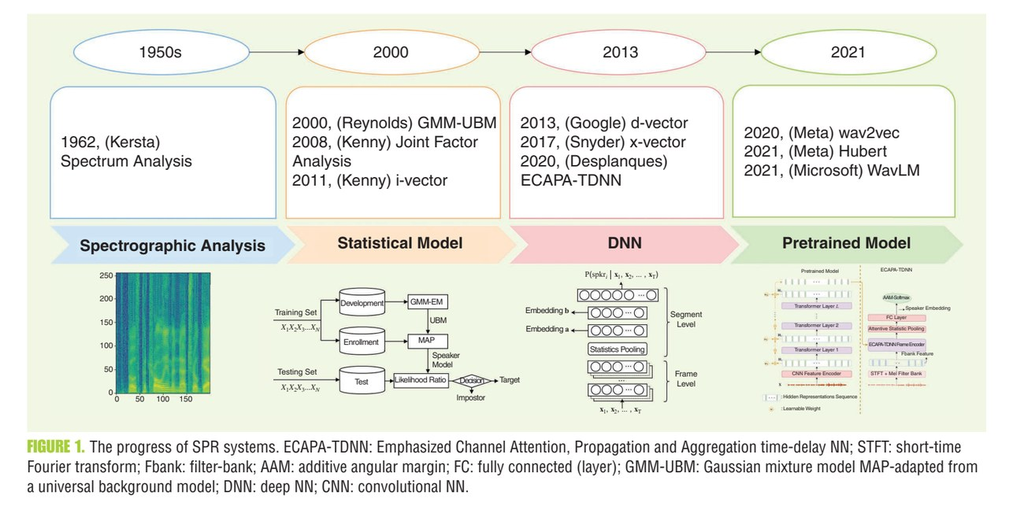

This is **speaker recognition** (“who spoke?”, W12), not ASR: and it walked the same road: spectrograms → statistical models → DNNs → pretrained models. The paradigm shifts swept every speech task at once.

Yu et al. (2023), “Twenty-Five Years of Evolution in Speech and Language Processing”, *IEEE Signal Processing Magazine* 40(5), Fig. 1. © IEEE, reproduced for teaching.

ɹ

Why you, specifically

## The hard problems are linguistics

### Coarticulation

No two /d/s are alike; every frame is context.

### Variation

Accents, dialects, sociolects: systems trained on *someone's* speech.

### Reduction

“probably” → [pɹɒbli]. Casual speech destroys dictionary forms.

### Prosody

Synthetic voices read sentences, not discourse. Still unsolved.

Commercial recognizers make **roughly twice the errors** for Black American speakers as for white speakers (Koenecke et al. 2020; we audit this ourselves in Week 9).  
The systems learned *someone's* phonology. Just not everyone's.

Activity · ~6 minutes, in pairs

## Same sentence, five speakers

You will hear one sentence read by five speakers: Singaporean, Malaysian, Indian, British, American.

**Predict, in pairs:** rank the five by how many errors the recognizer will make. Commit before the reveal.

Then we compare with the actual transcripts (pre-run, so no wifi drama).

THE QUESTION UNDERNEATH

If errors track accent, the system has learned *someone's* phonology. The Koenecke result on the previous slide is this observation, done properly, at scale. In Week 9, you run that audit yourselves.

Break · 10 minutes · back at 10:50

Stretch. Refill.  
Then: sounds become numbers.

When we return: what a recording actually is, and the first math this course runs on: vectors and similarity.

The reframe

## Recorded speech is a list of numbers

A sentence (~3 s · 48,000 numbers)

Zoom: one vowel (~30 ms), the wave repeats

Zoom again: the individual samples

**Sampling:** measure the wave at strict, regular intervals.  
16,000 of these per second is all a microphone gives the machine.  
**Everything else must be computed.**

Live · Praat

## Watch the list of numbers appear

**1.** Open week01_demo.wav (course repo)

**2.** Zoom: sentence → one vowel → single cycles

**3.** Keep zooming until the dots separate: **samples**

**4.** Click one dot and read its value: one number

Why this matters

The previous slide is a drawing; this is the real thing, in the tool you already know. Praat, matplotlib, and every recognizer in existence all start from these same dots.

The reframe · sampling, how often?

## How many samples per cycle?

1 per cycle · the wave vanishes

2 per cycle · peak and valley only: the Nyquist limit

5 per cycle · recognisable

10 per cycle · smooth

Grey: the real wave · coral dots: the samples · teal: what the numbers preserve

The **sampling theorem**: you need **more than two samples per cycle**. Half the sampling rate is the **Nyquist frequency**, the highest frequency a recording can hold: at 16,000 samples per second, 8,000 Hz. Sound above it? Week 3: aliasing.

The reframe · quantisation, how fine?

## Quantisation: every sample lands on a level

- Between the levels nothing can be stored: each sample **rounds to the nearest rung** (here 8 rungs = 3 bits)
- Playback reads the rungs back out; the gap between truth and rung is the **rounding error**
- Thousands of tiny rounding errors per second add up to **quantisation noise**: a real, audible hiss

More bits, finer rungs, quieter hiss: 16-bit audio has **65,536** of them and the error drops below hearing. In **Week 3** you listen to 16 → 8 → 4 → 3 bits and hear the rungs appear.

The reframe · quantisation, and back

## Quantise in, reconstruct out

[figure not shown]

After Coleman (2005), *Introducing Speech and Language Processing*, Fig. 2.5 (adapted from Embree 1991).

- Storage keeps **only the level number**: “30”, not 3.09 V. That direction is **analogue to digital**, written **A → D**: the recorder’s converter
- Playback runs it backwards, **digital to analogue** (**D → A**): it can only output each level’s **midpoint**, so everything from 3.0–3.1 V comes back as 3.05 V
- In 3.09, out 3.05: the 0.04 V gap is the **quantisation error**, and no later hardware can recover it

**Is this the only rule?** No: this figure rounds down and plays back the midpoint; the previous slide rounded to the **nearest** rung. Designs differ, but the guarantee is the same: the error is never more than **half a level**. At **16 bits** the levels are 1,024 times finer than these 64, and the locked-in error sinks below hearing.

The reframe · bits

## Binary: counting with 0 and 1

Place values, base 2

101₂ = 1×4 + 0×2 + 1×1 = **5**

Each place is worth twice the one to its right: …8, 4, 2, 1. Add the place values that sit over a 1, and skip the rest.

EX 1.1

Use the place values to convert 1011₂, then check it in the table. How many levels do 4 bits give, and what is the largest?

Worked answers in the appendix.

All sixteen 4-bit numbers

0000 = 01000 = 8 0001 = 11001 = 9 0010 = 21010 = 10 0011 = 31011 = 11 0100 = 41100 = 12 0101 = 51101 = 13 0110 = 61110 = 14 0111 = 71111 = 15

Left half starts with 0, right half with 1: one extra bit **doubles** the count. That is all 2ⁿ means.

The reframe · bits, doubled

## Every extra bit doubles the levels

The doubling law

1 bit → 2  
3 bits → 8  
8 bits → 256  
16 bits → 65,536

In Week 3 you will **hear** what each doubling buys: roughly 6 dB less quantisation noise.

EX 1.2

8-bit audio has 256 levels. How many does 16-bit have, and how many times finer is that?

Worked answers in the appendix.

| bits | levels = 2ⁿ | typical range | where you meet it |
| --- | --- | --- | --- |
| 1 | 2 | 0…1 | a switch: voiced / voiceless |
| 3 | 8 | 0…7 | the quantisation slide’s rungs |
| 8 | 256 | −128…127 | telephone-era audio |
| 16 | 65,536 | −32,768…32,767 | **speech & CD audio: int16** |
| 24 | 16,777,216 | huge | studio headroom |

Callbacks: the 8 rungs of the quantisation figure were the 3-bit row; real recordings live on the 16-bit row.

The reframe · data types

## A data type is a reading instruction

1 · IN THE RECORDER

### int16

Most recorders write 16-bit **whole numbers** into a WAV file. Studio kit: 24-bit; phone memos compress, then unpack.

2 · IN NUMPY

### float32

Loading divides every sample by 32,768: **8192 becomes 0.25**. The same wave, now decimals on one shared scale.

3 · IN THE SILICON

### only bit patterns

The type says **how to read** a pattern: place values for integers; sign, exponent, fraction for floats.

| type | bits | it holds | where you meet it |
| --- | --- | --- | --- |
| uint8 | 8 | 0…255 | telephone-era audio files |
| int16 | 16 | −32,768…32,767 | **WAV: recorders, CDs, our corpus** |
| float32 | 32 | decimals (about 7 digits) | **numpy audio, in [−1, 1]** |
| float64 | 64 | decimals (about 16 digits) | numpy’s everyday math |

After Coleman (2005), Table 2.5, translated into Python: his C types unsigned char / short / float / double are numpy’s uint8 / int16 / float32 / float64.

Why ÷ 32,768? Why [−1, 1]?

One **shared, unit-free scale**: 0.25 means a quarter of full loudness, whatever the file’s bit depth. And the trip is lossless: float32 holds every int16 exactly.

Overflow & headroom: why the float system wins

**Mix two loud voices** and you add their waves, sample by sample: 20,000 + 20,000 = 40,000, but a 16-bit box stops at 32,767. The sum **does not fit**: that is **overflow**, heard as harsh clipping. Floats have a ceiling too, but the movable decimal point (next slide) puts it near 10³⁸, and audio math never comes close: samples live in [−1, 1], so sums reach the thousands at most. That is **headroom**: a ceiling too far away to matter.

The reframe · inside a float

## float32 is scientific notation, in binary

You have written floats since secondary school: 6.02 × 10²³ is a **sign**, some **digits**, and an **exponent** saying where the point sits. float32 is the same trick in base 2, budgeted into 32 bits:

1

8 exponent bits

23 fraction bits

±

where the point sits: 2ᵉ, e from −126 to 127

the digits: about 7 significant decimal digits

0.25 = +1.0 × 2⁻² → **0** **01111101** **00000000000000000000000** (the exponent field stores −2 + 127 = 125 = 01111101₂)

EXPONENT BITS BUY RANGE

8 bits give 256 positions for the point: from 2⁻¹²⁶ up to 2¹²⁷, roughly 10±³⁸. That is the **headroom** of the last slide.

FRACTION BITS BUY PRECISION

23 bits of digits give about 7 decimal digits. Need more? float64 re-budgets: 11 exponent + 52 fraction, about 16 digits.

Why 8 and 23? It is a budget: exponent bits buy range, fraction bits buy precision, and the split is the compromise the whole computing world standardised in 1985 (IEEE 754).

The reframe · on one slide

## A recording is three choices

CHOICE 1 · SAMPLING RATE

### 16,000 per second

More than two samples per cycle, so 16 kHz keeps sound up to 8 kHz. Above that: gone.

CHOICE 2 · BIT DEPTH

### 16 bits · 65,536 levels

Every sample rounds to the nearest level; what remains of the rounding is a whisper of quantisation noise.

CHOICE 3 · DATA TYPE

### int16 or float32

Whole numbers on disk; floats in numpy, rescaled to [−1, 1]. Same wave, two rulers.

The same three samples, three ways

float32 [ 0.2500, 0.1250, 0.0625 ]  
int16 [ 8192, 4096, 2048 ]  
on disk 0010 0000 0000 0000 0001 0000 0000 0000 0000 1000 0000 0000

0.25 of full scale × 32,768 = 8192 = 2¹³: a single 1 in the 8192s place. Stored sound **is** these bit patterns: sixteen per sample, sixteen thousand samples per second.

The speech default: 16 kHz · 16-bit · loaded as float32. In **Week 3** you make each choice audible: aliasing, bit-depth ear-training, and the industry’s standard settings.

ʃ

The course mantra

Every system in this course is a recipe for turning one list of numbers into another.

ASR: 48,000 samples → 11 characters. TTS: 11 characters → 48,000 samples.

Math primer · I

## Functions are input → output machines

**spectrogram(**waveform**)** = the picture Praat draws for you

**g2p(**“enough”**)** = /ɪˈnʌf/ (grapheme-to-phoneme: spelling → IPA)

**asr(**audio**)** = “text”

A whole recognizer is just functions **composed**, like rules feeding rules in a phonological derivation:

asr = decode( score( features( record(you) ) ) )

i

Math primer · II

## A vowel token is a vector

Measure two formants, and a vowel becomes  
a **point in space** (an arrow from the origin).

/i/ = (270, 2290)  
F1 F2 (Hz)

Add F3, duration, spectral tilt… same idea, more axes.  
Past three dimensions you **lose the picture, not the math**.

| vowel | F1 (Hz) | F2 (Hz) |
| --- | --- | --- |
| i | 270 | 2290 |
| ɪ | 390 | 1990 |
| ɛ | 530 | 1840 |
| ɑ | 730 | 1090 |
| u | 300 | 870 |

Means, adult male speakers: Peterson & Barney (1952)

You've used a vector space since first year

## The vowel chart is a vector space

Phoneticians made this embedding **by hand**, decades before machine learning had a name for it.

Close on the chart ⇒ similar vowels.  
Distance means something.

So: can we give the machine  
a **number** for “how similar”?

+

Math primer · the moves you will reuse all term

## Vector arithmetic I: moves on arrows

Adding: tip to tail

[figure not shown]

Walk a, then walk b from a’s tip: a + b = (2, 1) + (1, 2) = (3, 3). Add coordinate by coordinate.

Scaling: new length, same direction

2a = (4, 2): twice as long, pointing exactly the same way. Scaling never changes direction: remember that for cosine.

Normalising: keep only the direction

Divide v by its own length: direction kept, size forgotten. Cosine similarity is secretly a dot product of unit vectors.

Each move is one line of numpy, and nothing here goes beyond addition and multiplication.

Math primer · the moves you will reuse all term

## Vector arithmetic II: moves on vowel data

[figure not shown]

The difference vector: a recipe

/ɪ/ − /i/ = (390 − 270, 1990 − 2290) = (+120, −300): the instructions for getting from /i/ to /ɪ/. Careful: in raw Hz the F2 change looks bigger, but proportionally F1 moves more (+44% vs −13%). Week 4’s delta features are this idea, applied over time.

The centroid: a prototype

x̄ = (x₁ + … + xₙ) / n: average each coordinate. The centroid of your /æ/ tokens is the category’s **prototype**: prototype theory, as arithmetic. You compute one in the practical (and again in EX 1.5).

★ The hardest idea this week

How similar are two sounds?

Two answers, both one line of arithmetic: the **dot product** (angle) and **Euclidean distance** (gap).  
Every system in this course asks this question *millions of times per second*.

Similarity, answer 1

## The dot product asks: do they point the same way?

a · b = a₁b₁ + a₂b₂

Multiply matching coordinates, add them up. What that measures: **how much of one arrow lies along the other**: the shadow b casts on a’s direction.

Lay a flat along the axis: a · b = a₁b₁ + 0 · b₂. The height b₂ never enters: **only the shadow survives**.

cos(a, b) = a · b / ( |a| |b| )

**Cosine similarity**: divide by both lengths and only direction remains: +1 = same direction, 0 = right angles. (All-positive formant vectors never get near 0.)

**Bookmark this operation.** In Week 3 it opens the Fourier transform: dot products with “probe” sine waves are how a computer reads the recipe of any sound.

One circle, no trigonometry homework

## What cos actually measures

Cosine is the **shadow** a unit arrow casts on the other arrow's direction.

cos 0° = **1** same direction, full shadow

cos 45° ≈ **0.71** halfway round, shorter shadow

cos 90° = **0** right angles, no shadow at all

That is all cosine similarity uses. Multiply the shadow by both lengths and you have the dot product: a · b = |a||b| cos θ.  
**Week 3 preview:** this circle starts spinning, and the arrow's height traces a sine wave, the blueprint of every sound.

Commit before we compute

cos( /i/, /ɪ/ ): nearer 0.9 or 0.999?

Hands up for each. Then a second guess: /ɑ/ is how many times farther from /i/ than /ɪ/ is? Write your number down.

(Most people guess the cosine too low. Watch what all-positive coordinates do to the angle.)

Worked example · by hand, once in your life

## Is /i/ more like /ɪ/ or /ɑ/?

/i/ = (270, 2290) /ɪ/ = (390, 1990) /ɑ/ = (730, 1090)

**i · ɪ** = (270 × 390) + (2290 × 1990) = 105,300 + 4,557,100 = **4,662,400**

lengths: |i| ≈ 2,306 |ɪ| ≈ 2,028 → cos = 4,662,400 / (2,306 × 2,028) ≈ **0.997**

**i · ɑ** = (270 × 730) + (2290 × 1090) = 2,693,200 → cos ≈ **0.890**

/i/ vs /ɪ/

cos 0.997 → 4.4° apart

/i/ vs /ɑ/

cos 0.890 → 27° apart

Verdict

The arithmetic agrees with your phonetics training. **That's the point.**

Similarity, answer 2

## Euclidean distance asks: how far apart?

d(a, b) = √( (a₁−b₁)² + (a₂−b₂)² )

d(i, ɪ) = √(120² + 300²) ≈ **323 Hz**

d(i, ɑ) = √(460² + 1200²) ≈ **1,285 Hz** (4× farther)

Just Pythagoras on the vowel chart: the straight-line gap between two points.

Remember this line

In **Week 5** you'll compute this exact quantity between MFCC frames, thousands of times, inside your own working digit recognizer.

np.sqrt(np.sum((a-b)**2))

One line of Python. You write it in the practical, at 12:40.

Before you compute alone

## The three ways this goes wrong

### Crossed wires

a · b multiplies **matching** coordinates: a₁b₁ + a₂b₂. If you ever write a₁b₂, stop and re-pair.

### The lost square root

Distance squares the gaps, then takes the root at the end. Squaring also kills minus signs: (−300)² = 90,000.

### The raw-Hz trap

F2's range is roughly 3× F1's, so raw-Hz distance is mostly an F2 story. Phoneticians normalize (Bark, Lobanov) for exactly this reason.

That third one is a preview: in **Week 4** the machine fixes its ruler too, bending the frequency axis to match the ear. It's called the **mel scale**, and you will build it yourself.

Exercises · pencils out · ~6 minutes, in pairs

## Try it: vowels as vectors

EX 1.3

Peterson & Barney means: /u/ = (300, 870), /ɔ/ = (570, 840), /ɑ/ = (730, 1090). (a) Compute d(/u/, /ɔ/). (b) Which of /u/ and /ɔ/ is closer to /ɑ/? Check your verdict against the vowel chart.

EX 1.4

Let a = (1, 2) and b = (2, 4). Compute cos(a, b) *and* d(a, b). What does this pair of answers tell you that either alone would not?

EX 1.5

Three /æ/ tokens: (650, 1700), (670, 1740), (690, 1720). Find the centroid.

EX 1.6

One Singaporean speaker's /ɛ/, measured in Praat: (580, 1850). Peterson & Barney (US, 1952): /ɛ/ = (530, 1840), /æ/ = (660, 1720). Which is it closer to? And what can you *not* conclude from one token?

Worked answers in the appendix at the end of this deck.

ɑ

Why two measures?

## Angle forgives, distance doesn't

A child's /i/ and an adult's /i/ sit **far apart** on the chart: shorter vocal tract, all formants scaled up.

But the vectors still **point the same way**: big distance, tiny angle.

Choosing a similarity measure is a **theoretical claim** about what counts as “the same sound”: speaker normalization, in your terms.

RUNNING THEME

This tension (*what should the machine treat as equivalent?*) returns as:

• cross-speaker failure W5  
• learned representations W7  
• accent bias in ASR W9

M

One more object · vectors in bulk

## A matrix is vectors, stacked

- A matrix is a rectangular table of numbers; its **shape** is rows × columns
- Each row here is one vowel's (F1, F2): eight vectors, one object
- Your practical's CSV loads as exactly this table, forty rows deep

DEFINITION

Matrix

An m × n matrix is an array of numbers in m rows and n columns; the product A x applies each row's weighted sum to the vector x.

Deisenroth et al. (2020), ch. 2.

The only new operation you need this term

## Matrix × vector: many dot products at once

- Each output entry is **one row's dot product** with x: the operation you just learned, run once per row

The shape rule

An m × n matrix times a length-n vector gives a length-m vector. The inner sizes must agree; the outer size is what you get.

Remember this line

A @ x

One character in numpy. In **Week 4** the rows become 26 mel filters; in **Week 7** the same line runs with learned weights. This slide is a promise.

What a matrix does · one transform, every point

## A matrix moves the whole vowel space at once

S has rows (1.25, 0), (0, 1.25) · S · (270, 2290) = (338, 2863)

EX 1.7

Write the diagonal matrix that leaves F1 unchanged and doubles F2, then apply it to /u/ = (300, 870).

Chaining transforms

## Two matrices in a row are one matrix

G has rows (2, 0), (0, 3) · H has rows (1, 1), (0, 1) · x = (1, 1)

first G: G x = (2 × 1, 3 × 1) = (2, 3)

then H: H (G x) = (2 + 3, 3) = (**5**, **3**)

the shortcut: H G has rows (2, 3), (0, 3), and (H G) x = (**5**, **3**): the same answer, one multiply

[figure not shown]

Why it matters

A chain of matrix steps, however long, collapses into a single matrix. Linear pipelines cannot build anything one multiply could not.

Two seeds, planted

**Week 4:** the front end runs matrix, then log, then matrix; the log between them is exactly what keeps the two from fusing. **Week 7:** neural networks put a squash between layers for the same reason: without the bend, depth collapses.

Why bother, concretely

## Three matrices already on your calendar

WEEK 3

### The spectrogram

The picture itself is a matrix: frequencies down the rows, one 10 ms spectrum per column. You will read one before you compute one.

WEEK 4

### The mel filterbank

Twenty-six rows, each a triangular ear. One multiply, filterbank @ spectrum, turns a spectrum into 26 loudnesses.

WEEK 7

### A neural layer

The same multiply with weights learned from data, plus one squash: the building block of every modern speech system in this course.

EX 1.8

B has rows (1, 2), (3, 0) and (0, 1), so B is 3 × 2. Let y = (10, 5). State the shape of B y first, then compute it row by row.

EX 1.9

Week 4's filterbank is a 26 × 257 matrix and a spectrum is a length-257 vector. What is the shape of filterbank @ spectrum? And why can you not multiply them the other way round?

Worked answers in the appendix at the end of this deck.

In the textbook's words

## This week, formally

DEFINITION

Vector

An ordered n-tuple of real numbers v = (v₁, …, vₙ) ∈ ℝⁿ; geometrically, a point (or an arrow from the origin) in n-dimensional space.

Deisenroth, Faisal & Ong (2020), *Mathematics for Machine Learning*, ch. 2.

DEFINITION

Dot product

For a, b ∈ ℝⁿ: a · b = a₁b₁ + … + aₙbₙ = |a| |b| cos θ, where θ is the angle between a and b.

DEFINITION

Matrix

An m × n matrix is an array of numbers in m rows and n columns; the product A x applies each row’s weighted sum to the vector x.

Deisenroth et al. (2020), ch. 2.

DEFINITION

Cosine similarity

cos(a, b) = a · b / ( |a| |b| ), ranging over [−1, 1]; for non-negative measurements (formant values, counts) the range is [0, 1].

DEFINITION

Euclidean distance

d(a, b) = √( Σᵢ (aᵢ − bᵢ)² ): the straight-line distance between two points; Pythagoras, in any number of dimensions.

Deisenroth et al. (2020), §3.1.

Break · 10 minutes · back at 11:50

Open your laptop.  
The Colab link is on NTULearn.

No installs, no setup: if you can open a browser tab, you are ready.

The practical · 11:50–12:50

## From zero to a vowel space you built

- Run your first Python, in the browser, nothing to install
- Loops & lists over real formant data
- numpy: means, difference vectors
- Plot the IPA vowel chart *from numbers*
- Cosine similarity & distance: today's lecture, executable

**Stretch (or take-home):** a nearest-neighbour “vowel guesser”: drop in your own Praat measurements and see where your accent lands.

You leave with this, made by you

The practical · your first five minutes, scripted

## Nothing to install, one thing to break

**1.** Open the Week 1 Colab link (NTULearn → Practicals)

**2.** Run the first cell: Shift + Enter

**3.** Run the data cell: one wget fetches every file we use today

**4.** Run the cell that is **designed to fail**, and read the error aloud with me

Step 4 fails **on purpose**. An error message is the computer telling you what went wrong and where, not a judgement on you. You will meet many this term; we read the first one together so they never feel scary.

The practical · survival kit I

## Paths: every file has an address

Read it right to left

/content/data/vowels.csv

A file vowels.csv, inside a folder data, inside a folder content, inside / : the **root**, the outermost folder of the whole machine.

ABSOLUTE PATH

/content/data/vowels.csv  
Starts with **/** : directions from the root. Works no matter where you stand.

RELATIVE PATH

data/vowels.csv  
No leading slash: directions from **where you are standing**. .. is the folder above; . is here; ~ is your home folder.

Which slash?

Mac and Linux write paths with the forward slash /. Windows uses the backslash \ on your own laptop. Here it will never matter: a Colab notebook runs on a **Linux machine in the cloud**, so whatever laptop you bring, everyone types /.

The practical · survival kit II

## Three commands: pwd, ls, cd

```
$ pwd
/content            ← where am I standing?
$ ls                  ← what is here?
data  sample_data
$ cd data             ← step into data
$ pwd
/content/data
$ cd ..                ← up one level
$ cd -                 ← back where I just was
$ cd /                 ← jump to the root
$ cd ~                 ← jump to your home folder
```

In Colab

Prefix shell commands with ! : !pwd, !ls (you already ran !wget today). One catch: !cd does **not stick**: every ! line opens a fresh shell. To actually move, use %cd data.

Why learn this

In **Week 9** you drive a real command-line tool, the Montreal Forced Aligner, with exactly these three commands.

Your files in Colab

Downloads land in /content, which is **wiped when the runtime shuts down**. To keep work, mount your Drive: drive.mount('/content/drive') → your files appear under /content/drive/MyDrive/.

On your own machine (optional)

**Mac:** the Terminal app (Applications → Utilities, or Spotlight “Terminal”). **Windows:** PowerShell or Windows Terminal: pwd, ls and cd work there too (the older cmd.exe spells things differently). Nothing in this course requires a local terminal: Colab gives everyone the same Linux shell in the browser.

The practical · the hour, mapped

## By the end of the hour, you will have built this

**1.** Orientation: paths, pwd / ls / cd, the deliberate error (15 min)

**2.** Lists & loops over real formant data (10 min)

**3.** numpy: means & difference vectors (10 min)

**4.** Plot the vowel space, axes flipped (15 min)

**5.** Similarity two ways: cosine & distance (10 min)

DONE LOOKS LIKE

✓ a vowel-space plot, IPA labels, axes reversed  
✓ every vowel ranked by similarity to /i/  
✓ one error message you fixed yourself  
✓ pwd, ls and cd in your fingers

The vowel-guesser stretch is take-home if the hour runs out. This notebook's skills return in Assignment 1.

The course book

## One free book underneath it all

Speech and Language Processing

Daniel Jurafsky & James H. Martin  
3rd edition (online draft)

web.stanford.edu/~jurafsky/slp3

Free chapter PDFs. Nothing to buy, ever.

- The field’s standard textbook, and it is **free online**
- A **living draft**, updated continually: we cite the **August 2026 release**, and chapter numbers move between releases, so follow the syllabus’s numbers
- Our chapters: Ch 3 n‑grams (W2, W6) · Ch 15 phonetics & features (W3–4) · Ch 16 ASR (W5–9) · Ch 17 TTS (W10–12) · Ch 25 conversation (W13)

Before next week

## This week’s readings

REQ**Jurafsky & Martin, *Speech and Language Processing* (3rd ed., free online): Ch 16 & 17, intros only**

Just the chapter openings of the ASR and TTS chapters: the bird's-eye view of today's two pipelines. web.stanford.edu/~jurafsky/slp3 (chapter numbers follow the Aug 2026 draft)

REQ**3Blue1Brown, *Essence of Linear Algebra*: “Vectors”, “Dot products”, “Linear transformations and matrices” & “Matrix multiplication as composition” (~45 min video)**

The geometric picture from today, animated better than any slide; the last two episodes are today's matrix slides, moving. 3blue1brown.com/lessons/ vectors · dot-products · linear-transformations · matrix-multiplication

OPT**VanderPlas, *A Whirlwind Tour of Python* (free)**

Keep open as a reference during practicals; variables, lists, loops are all we use for two weeks.

OPT**Deisenroth, Faisal & Ong, *Mathematics for Machine Learning* (free PDF) · opening of Ch 2**

Only for the math-hungry: the formal version of today's definitions. mml-book.github.io

Looking one week ahead

## Next week’s readings

REQ**Goldsmith (2007), “Probability for linguists”**

Written exactly for this audience: probability taught through phones and words, no engineering background assumed. Free online.

REQ**Jurafsky & Martin, *SLP* Ch 3 “N-gram Language Models”: §3.1–3.3 and the perplexity section**

Skip smoothing for now: it returns in Week 6. (Chapter numbers follow the Aug 2026 draft.)

REQ**3Blue1Brown, “Bayes theorem, the geometry of changing beliefs” (15 min video)**

Next week’s hardest idea, animated: watch it before Friday and the lecture will feel like revision.

OPT**Shannon (1951), “Prediction and Entropy of Printed English”**

The paper behind Week 2’s guessing game; surprisingly readable.

OPT*Seeing Theory* (Brown University)

Interactive probability, almost no prose: play with it for ten minutes.

**Next week:** probability & Bayes’ rule, the math of a listener’s guesses. “wreck a nice beach” awaits.

Wrap-up · quiz radar

## Six things to walk out with

- Compute a 2-D dot product and a Euclidean distance by hand
- Say when cosine beats distance (the child/adult /i/ story)
- Read a difference vector as a recipe between vowels
- Multiply a small matrix by a vector, row by row, and say why the shapes must agree
- Explain “recorded speech is a list of numbers” to a friend
- Name one thing the recognizer did to the Singlish sentence, and why it matters

Exit ticket before you leave: one sentence, what is still muddiest? (form link on NTULearn)

ə

One list of numbers  
into another.

That's the whole course. See you in the lab.

Sources

## References

**Coleman, J.** (2005). *Introducing Speech and Language Processing.* Cambridge University Press. Ch. 2 “Sounds and numbers”: sampling, quantisation & reconstruction (Fig. 2.5), data types (Table 2.5).

**Hannun, A.** (2021). “The History of Speech Recognition to the Year 2030.” awni.github.io/future-speech. Basis of the 2010–2020 timeline.

**Traunmüller, H.** “Wolfgang von Kempelen’s speaking machine and its successors.” Stockholm University. resources.ling.su.se/hartmut/kemplne.html. The early-machines tour and images.

**Klatt, D. H.** (1987). “Review of text-to-speech conversion for English.” *Journal of the Acoustical Society of America* 82(3), 737–793. Historical recordings from Klatt’s archive, via Acoustics Today (acousticstoday.org).

**Yu, D. et al.** (2023). “Twenty-Five Years of Evolution in Speech and Language Processing.” *IEEE Signal Processing Magazine* 40(5), 27–39. Fig. 1 reproduced.

**Koenecke, A. et al.** (2020). “Racial disparities in automated speech recognition.” *PNAS* 117(14), 7684–7689.

**Peterson, G. E. & Barney, H. L.** (1952). “Control methods used in a study of the vowels.” *JASA* 24(2), 175–184. The formant means used throughout this deck.

**Images:** Wikimedia Commons (public domain) and H. Traunmüller. **Recordings:** D. H. Klatt’s history-of-synthesis archive, via Acoustics Today.

Appendix · worked answers

## Answers · I

EX 1.1

1011₂ = 8 + 0 + 2 + 1 = **11** (check: row 1011 of the table). Four bits give 2⁴ = **16** levels; the largest is 1111₂ = **15**.

EX 1.2

2¹⁶ = **65,536** levels: 65,536 ⁄ 256 = **256 times finer**. Each extra bit doubles the levels and buys about 6 dB less noise (Week 3).

EX 1.3

(a) Δ = (270, 30) → d = √(72 900 + 900) = √73 800 ≈ **272 Hz**.  
(b) d(/u/, /ɑ/) = √(430² + 220²) ≈ 483 Hz; d(/ɔ/, /ɑ/) = √(160² + 250²) ≈ 297 Hz → **/ɔ/ is closer**, exactly what the chart shows.

EX 1.4

a · b = 2 + 8 = 10; |a| = √5, |b| = √20, |a||b| = 10 → **cos = 1** (perfectly collinear). But d = √(1² + 2²) = √5 ≈ **2.24**.  
Same direction, different magnitude: the angle says “identical quality”, the distance says “different point”. The small-vs-large vocal tract situation, in miniature.

EX 1.5

Centroid = ( (650+670+690)/3 , (1700+1740+1720)/3 ) = ( 2010/3 , 5160/3 ) = **(670, 1720)**: the mean vector, component by component. (Exactly how we summarise a speaker's vowel space, and how k-means will later find clusters.)

Appendix · worked answers

## Answers · II

EX 1.6

d(to /ɛ/) = √(50² + 10²) ≈ **51 Hz**; d(to /æ/) = √(80² + 130²) ≈ **153 Hz** → closer to P&B /ɛ/. What you cannot conclude: anything about Singapore English generally. One token from one speaker is an anecdote; in Week 3 you measure your own vowels, and in Week 9 you learn to do this at corpus scale.

EX 1.7

Rows (1, 0) and (0, 2). Applied to /u/: 1×300 + 0×870 = **300**; 0×300 + 2×870 = **1740**, so the result is **(300, 1740)**: F1 untouched, F2 doubled. Diagonal entries are per-axis volume knobs; the off-diagonal zeros mean the axes do not mix.

EX 1.8

Shape first: B is 3 × 2 and y has length 2, so B y has length **3**. Rows: 1×10 + 2×5 = **20**; 3×10 + 0×5 = **30**; 0×10 + 1×5 = **5**. So B y = **(20, 30, 5)**: three weighted sums, one object. In Week 4 the rows are mel filters and the three becomes twenty-six.

EX 1.9

(26 × 257) times a length-257 vector: inner sizes agree, so the result has length **26**: one loudness per mel filter. The other way round fails the shape rule: a length-257 vector against 26 rows has no matching inner size. Order matters in matrix multiplication, and the shapes tell you which order is meaningful.